# Customer Churn Prediction — Logistic Regression

A Complete Teaching Notebook | From Data to Insight

Instructor Edition

2026-04-21

# 1 🎓 Welcome — What This Notebook Teaches

> This notebook is designed to teach you **Logistic Regression from scratch** using a real-world telecom churn dataset. Every decision is explained. Every line of code has a comment. By the end, you will know not just *how* to run logistic regression in R, but **why** each step matters.

## 1.1 The Business Problem

A telecom company wants to know: **which customers are likely to cancel their subscription (churn)?**

If we can predict churn **before** it happens, the business can intervene — offer discounts, improve service, or reach out proactively — and save revenue.

This is a **supervised binary classification** problem:

| Label | Meaning |
| --- | --- |
| `1` (Yes) | Customer **churned** — cancelled their service |
| `0` (No) | Customer **stayed** — did not cancel |

## 1.2 Why Logistic Regression (Not Linear Regression)?

This is the first question every student asks. Here is the honest answer:

**Linear regression predicts a continuous number** — like house price, or temperature. If you forced it to predict churn, it could output `1.8` or `-0.3`, which are **not valid probabilities**.

**Logistic regression wraps the linear predictor** inside a **sigmoid (logistic) function**:

$$P(\text{churn} = 1) = \frac{1}{1 + e^{-(\beta_0 + \beta_1 x_1 + \cdots + \beta_n x_n)}}$$

The sigmoid function **squishes any real number into the range (0, 1)**, giving us a valid probability. This is why logistic regression is the natural choice for binary outcomes.

## 1.3 🗺️ Roadmap — What We Will Do

| Step | Task | Why It Matters |
| --- | --- | --- |
| 1 | Load libraries | Tools we need |
| 2 | Load & explore data | Understand what we are working with |
| 3 | Make response variable categorical | Required for `glm()` to run logistic, not linear, regression |
| 4 | Select features with correlation | Remove noise, reduce multicollinearity |
| 5 | Normalise features | Ensure the optimizer converges properly |
| 6 | Train the model | Fit logistic regression |
| 7 | Evaluate with loss function + metrics | Measure how well we did |
| 8 | Interpret results | Understand what the model is telling us |

# 2 Step 1 — Load Libraries

> **Teaching note:** In R, we load all packages at the top of the notebook. This makes dependencies explicit and prevents cryptic “function not found” errors mid-analysis.

```r
# ── Core data wrangling & visualisation ──────────────────────────────────────
library(tidyverse)     # umbrella package: dplyr, ggplot2, readr, tidyr, purrr
library(corrplot)      # heatmap-style correlation matrix visualisation
library(scales)        # nice axis labels: percent(), comma(), dollar()

# ── Machine learning pipeline ─────────────────────────────────────────────────
library(caret)         # createDataPartition, preProcess, confusionMatrix

# ── Model evaluation ──────────────────────────────────────────────────────────
library(pROC)          # ROC curve and AUC-ROC metric
library(MLmetrics)     # LogLoss — the actual loss function logistic regression minimises

# ── Coefficient interpretation ────────────────────────────────────────────────
library(broom)         # tidy() — converts messy model output into clean data frames

# ── Table formatting ──────────────────────────────────────────────────────────
library(knitr)         # kable() — renders HTML tables
library(kableExtra)    # extra styling for kable tables

cat("✅ All libraries loaded successfully.\n")
```

```
✅ All libraries loaded successfully.
```

# 3 Step 2 — Load & Explore the Data

> **Teaching note:** Never skip EDA (Exploratory Data Analysis). Models are only as good as your understanding of the data. EDA reveals: missing values, unusual ranges, class imbalance, and which features look promising before any modelling begins.

## 3.1 2a — Load the Dataset

```r
# ── Load the CSV ───────────────────────────────────────────────────────────────
# read_csv() from readr (part of tidyverse) is faster and more consistent than
# base R's read.csv(). It never converts strings to factors automatically.
#
# IMPORTANT: ChurnData.csv must be in your working directory.
# Check with: getwd()
# Change with: setwd("path/to/your/folder")

df <- read_csv("ChurnData.csv")

# ── Quick overview ─────────────────────────────────────────────────────────────
cat("━━━━━━━━━━━━━━━━━━━━━━━━━━━━━━━━━━━\n")
```

```
━━━━━━━━━━━━━━━━━━━━━━━━━━━━━━━━━━━
```

```r
cat(" DATASET OVERVIEW\n")
```

```
 DATASET OVERVIEW
```

```r
cat("━━━━━━━━━━━━━━━━━━━━━━━━━━━━━━━━━━━\n")
```

```
━━━━━━━━━━━━━━━━━━━━━━━━━━━━━━━━━━━
```

```r
cat(sprintf("  Rows    : %d customers\n",  nrow(df)))
```

```
  Rows    : 200 customers
```

```r
cat(sprintf("  Columns : %d features\n\n", ncol(df)))
```

```
  Columns : 28 features
```

```r
# Preview: first 6 rows
head(df) %>%
  kable(caption = "📋 First 6 rows of ChurnData — a quick sanity check") %>%
  kable_styling(bootstrap_options = c("striped", "hover", "condensed"),
                full_width = FALSE, font_size = 12)
```

📋 First 6 rows of ChurnData — a quick sanity check

| tenure | age | address | income | ed | employ | equip | callcard | wireless | longmon | tollmon | equipmon | cardmon | wiremon | longten | tollten | cardten | voice | pager | internet | callwait | confer | ebill | loglong | logtoll | lninc | custcat | churn |
| --- | --- | --- | --- | --- | --- | --- | --- | --- | --- | --- | --- | --- | --- | --- | --- | --- | --- | --- | --- | --- | --- | --- | --- | --- | --- | --- | --- |
| 11 | 33 | 7 | 136 | 5 | 5 | 0 | 1 | 1 | 4.40 | 20.75 | 0.0 | 15.25 | 35.7 | 42.00 | 211.45 | 125 | 1 | 1 | 0 | 1 | 1 | 0 | 1.482 | 3.033 | 4.913 | 4 | 1 |
| 33 | 33 | 12 | 33 | 2 | 0 | 0 | 0 | 0 | 9.45 | 0.00 | 0.0 | 0.00 | 0.0 | 288.80 | 0.00 | 0 | 0 | 0 | 0 | 0 | 0 | 0 | 2.246 | 3.240 | 3.497 | 1 | 1 |
| 23 | 30 | 9 | 30 | 1 | 2 | 0 | 0 | 0 | 6.30 | 0.00 | 0.0 | 0.00 | 0.0 | 157.05 | 0.00 | 0 | 0 | 0 | 0 | 0 | 1 | 0 | 1.841 | 3.240 | 3.401 | 3 | 0 |
| 38 | 35 | 5 | 76 | 2 | 10 | 1 | 1 | 1 | 6.05 | 45.00 | 50.1 | 23.25 | 64.9 | 239.55 | 1873.05 | 880 | 1 | 1 | 1 | 1 | 1 | 1 | 1.800 | 3.807 | 4.331 | 4 | 0 |
| 7 | 35 | 14 | 80 | 2 | 15 | 0 | 1 | 0 | 7.10 | 22.00 | 0.0 | 23.75 | 0.0 | 47.45 | 166.10 | 145 | 1 | 0 | 0 | 1 | 1 | 0 | 1.960 | 3.091 | 4.382 | 3 | 0 |
| 68 | 52 | 17 | 120 | 1 | 24 | 0 | 1 | 0 | 20.70 | 0.00 | 0.0 | 22.00 | 0.0 | 1391.05 | 0.00 | 1505 | 0 | 0 | 0 | 0 | 0 | 0 | 3.030 | 3.240 | 4.787 | 1 | 0 |

## 3.2 2b — Data Types & Structure

```r
# glimpse() is the tidyverse equivalent of str() or Python's df.info()
# It tells us: column names, data types, and a preview of values
#
# KEY OBSERVATION: All columns are <dbl> (numeric).
# This means 'churn' is currently stored as 0/1 numbers — NOT as a category.
# We MUST fix this before modelling (Step 3 explains why).

glimpse(df)
```

```
Rows: 200
Columns: 28
$ tenure   <dbl> 11, 33, 23, 38, 7, 68, 42, 9, 35, 49, 56, 47, 56, 69, 16, 4, …
$ age      <dbl> 33, 33, 30, 35, 35, 52, 40, 21, 50, 51, 52, 40, 50, 51, 27, 3…
$ address  <dbl> 7, 12, 9, 5, 14, 17, 7, 1, 26, 27, 28, 16, 1, 11, 5, 16, 3, 3…
$ income   <dbl> 136, 33, 30, 76, 80, 120, 37, 17, 140, 63, 49, 127, 80, 438, …
$ ed       <dbl> 5, 2, 1, 2, 2, 1, 2, 2, 2, 4, 2, 4, 2, 4, 3, 5, 5, 5, 3, 1, 2…
$ employ   <dbl> 5, 0, 2, 10, 15, 24, 8, 2, 21, 19, 12, 12, 24, 23, 5, 6, 11, …
$ equip    <dbl> 0, 0, 0, 1, 0, 0, 1, 0, 0, 0, 0, 1, 0, 1, 0, 1, 1, 1, 1, 0, 0…
$ callcard <dbl> 1, 0, 0, 1, 1, 1, 1, 0, 1, 1, 1, 1, 1, 1, 0, 0, 0, 1, 1, 1, 1…
$ wireless <dbl> 1, 0, 0, 1, 0, 0, 1, 0, 0, 0, 0, 0, 1, 0, 0, 1, 0, 1, 0, 0, 0…
$ longmon  <dbl> 4.40, 9.45, 6.30, 6.05, 7.10, 20.70, 8.25, 2.90, 6.50, 12.85,…
$ tollmon  <dbl> 20.75, 0.00, 0.00, 45.00, 22.00, 0.00, 23.50, 0.00, 27.50, 25…
$ equipmon <dbl> 0.00, 0.00, 0.00, 50.10, 0.00, 0.00, 36.90, 0.00, 0.00, 0.00,…
$ cardmon  <dbl> 15.25, 0.00, 0.00, 23.25, 23.75, 22.00, 28.00, 0.00, 35.00, 1…
$ wiremon  <dbl> 35.70, 0.00, 0.00, 64.90, 0.00, 0.00, 37.40, 0.00, 0.00, 0.00…
$ longten  <dbl> 42.00, 288.80, 157.05, 239.55, 47.45, 1391.05, 399.15, 25.25,…
$ tollten  <dbl> 211.45, 0.00, 0.00, 1873.05, 166.10, 0.00, 950.65, 0.00, 1068…
$ cardten  <dbl> 125, 0, 0, 880, 145, 1505, 1190, 0, 1215, 635, 1215, 680, 106…
$ voice    <dbl> 1, 0, 0, 1, 1, 0, 1, 0, 0, 0, 0, 0, 1, 0, 0, 1, 0, 1, 0, 0, 0…
$ pager    <dbl> 1, 0, 0, 1, 0, 0, 0, 0, 0, 0, 0, 0, 1, 1, 0, 1, 1, 0, 0, 0, 0…
$ internet <dbl> 0, 0, 0, 1, 0, 0, 1, 0, 0, 1, 0, 1, 0, 1, 0, 1, 1, 1, 0, 0, 0…
$ callwait <dbl> 1, 0, 0, 1, 1, 0, 1, 0, 1, 1, 0, 0, 1, 0, 0, 1, 0, 0, 0, 1, 0…
$ confer   <dbl> 1, 0, 1, 1, 1, 0, 1, 0, 1, 0, 0, 0, 1, 1, 0, 1, 0, 1, 1, 1, 0…
$ ebill    <dbl> 0, 0, 0, 1, 0, 0, 1, 0, 0, 1, 0, 1, 0, 0, 0, 1, 1, 1, 1, 0, 0…
$ loglong  <dbl> 1.482, 2.246, 1.841, 1.800, 1.960, 3.030, 2.110, 1.065, 1.872…
$ logtoll  <dbl> 3.033, 3.240, 3.240, 3.807, 3.091, 3.240, 3.157, 3.240, 3.314…
$ lninc    <dbl> 4.913, 3.497, 3.401, 4.331, 4.382, 4.787, 3.611, 2.833, 4.942…
$ custcat  <dbl> 4, 1, 3, 4, 3, 1, 4, 1, 3, 2, 2, 2, 4, 4, 1, 4, 2, 2, 3, 3, 1…
$ churn    <dbl> 1, 1, 0, 0, 0, 0, 0, 0, 0, 0, 0, 0, 0, 0, 0, 1, 0, 0, 0, 1, 0…
```

## 3.3 2c — Summary Statistics

```r
# summary() gives us the 5-number summary + mean for every column
#
# KEY OBSERVATIONS to look for:
#   - Wide ranges: 'income' goes up to ~1600 vs 'wireless' which is binary (0/1)
#     → This tells us normalisation is essential (Step 5)
#   - Min = Max for any column → zero variance, useless feature
#   - NAs in the summary → missing data to handle

summary(df)
```

```
     tenure           age           address          income
 Min.   : 1.00   Min.   :19.00   Min.   : 0.00   Min.   :   9.00
 1st Qu.:16.75   1st Qu.:31.00   1st Qu.: 3.00   1st Qu.:  31.00
 Median :33.50   Median :40.00   Median : 9.00   Median :  48.00
 Mean   :35.51   Mean   :41.16   Mean   :11.65   Mean   :  75.13
 3rd Qu.:55.25   3rd Qu.:51.00   3rd Qu.:18.00   3rd Qu.:  80.00
 Max.   :72.00   Max.   :76.00   Max.   :48.00   Max.   :1668.00
       ed            employ          equip          callcard        wireless
 Min.   :1.000   Min.   : 0.00   Min.   :0.000   Min.   :0.000   Min.   :0.00
 1st Qu.:2.000   1st Qu.: 3.00   1st Qu.:0.000   1st Qu.:0.000   1st Qu.:0.00
 Median :3.000   Median : 7.50   Median :0.000   Median :1.000   Median :0.00
 Mean   :2.825   Mean   :10.22   Mean   :0.425   Mean   :0.705   Mean   :0.29
 3rd Qu.:4.000   3rd Qu.:17.00   3rd Qu.:1.000   3rd Qu.:1.000   3rd Qu.:1.00
 Max.   :5.000   Max.   :44.00   Max.   :1.000   Max.   :1.000   Max.   :1.00
    longmon          tollmon         equipmon        cardmon
 Min.   : 1.100   Min.   : 0.00   Min.   : 0.00   Min.   :  0.00
 1st Qu.: 5.537   1st Qu.: 0.00   1st Qu.: 0.00   1st Qu.:  0.00
 Median : 8.250   Median : 0.00   Median : 0.00   Median : 12.50
 Mean   :11.789   Mean   :13.24   Mean   :15.78   Mean   : 14.36
 3rd Qu.:14.300   3rd Qu.:24.75   3rd Qu.:33.01   3rd Qu.: 20.75
 Max.   :62.300   Max.   :68.50   Max.   :63.25   Max.   :109.25
    wiremon          longten           tollten          cardten
 Min.   :  0.00   Min.   :   1.10   Min.   :   0.0   Min.   :   0.0
 1st Qu.:  0.00   1st Qu.:  79.34   1st Qu.:   0.0   1st Qu.:   0.0
 Median :  0.00   Median : 289.52   Median :   0.0   Median : 342.5
 Mean   : 12.22   Mean   : 577.77   Mean   : 507.0   Mean   : 650.7
 3rd Qu.: 23.46   3rd Qu.: 806.76   3rd Qu.: 724.2   3rd Qu.: 921.2
 Max.   :109.70   Max.   :4333.00   Max.   :4938.6   Max.   :7515.0
     voice           pager          internet       callwait         confer
 Min.   :0.000   Min.   :0.000   Min.   :0.00   Min.   :0.000   Min.   :0.00
 1st Qu.:0.000   1st Qu.:0.000   1st Qu.:0.00   1st Qu.:0.000   1st Qu.:0.00
 Median :0.000   Median :0.000   Median :0.00   Median :0.000   Median :0.00
 Mean   :0.295   Mean   :0.275   Mean   :0.44   Mean   :0.455   Mean   :0.46
 3rd Qu.:1.000   3rd Qu.:1.000   3rd Qu.:1.00   3rd Qu.:1.000   3rd Qu.:1.00
 Max.   :1.000   Max.   :1.000   Max.   :1.00   Max.   :1.000   Max.   :1.00
     ebill         loglong         logtoll          lninc          custcat
 Min.   :0.00   Min.   :0.095   Min.   :1.749   Min.   :2.197   Min.   :1.000
 1st Qu.:0.00   1st Qu.:1.712   1st Qu.:3.227   1st Qu.:3.434   1st Qu.:2.000
 Median :0.00   Median :2.110   Median :3.240   Median :3.871   Median :2.000
 Mean   :0.44   Mean   :2.193   Mean   :3.229   Mean   :3.951   Mean   :2.475
 3rd Qu.:1.00   3rd Qu.:2.660   3rd Qu.:3.240   3rd Qu.:4.382   3rd Qu.:3.000
 Max.   :1.00   Max.   :4.132   Max.   :4.227   Max.   :7.419   Max.   :4.000
     churn
 Min.   :0.00
 1st Qu.:0.00
 Median :0.00
 Mean   :0.29
 3rd Qu.:1.00
 Max.   :1.00
```

## 3.4 2d — Missing Value Check

```r
# Missing values are a silent killer of model quality.
# We check every column before proceeding.

missing_counts <- colSums(is.na(df))

if (sum(missing_counts) == 0) {
  cat("✅ No missing values found. Clean dataset — we can proceed.\n")
} else {
  cat("⚠️  Missing values detected:\n")
  missing_counts[missing_counts > 0] %>%
    as.data.frame() %>%
    setNames("Missing Count") %>%
    kable(caption = "Columns with missing values") %>%
    kable_styling(bootstrap_options = "striped", full_width = FALSE)
}
```

```
✅ No missing values found. Clean dataset — we can proceed.
```

# 4 Step 3 — ⚠️ Response Variable: Cast to Factor (Categorical)

> **This is one of the most important steps. Read carefully.**

## 4.1 Why This Step Cannot Be Skipped

When `churn` is stored as a **numeric** column (0.0 / 1.0), R’s `glm()` function sees it as a **continuous outcome** and fits **linear** regression — not logistic regression. This produces:

- Predictions outside [0, 1] (impossible probabilities)
- Incorrect coefficients
- No meaningful probability interpretation

By converting `churn` to a **factor**, we explicitly tell `glm()`: *“This is a categorical outcome — use logistic regression with a sigmoid link function.”*

```r
# ── BEFORE: numeric ─────────────────────────────────────────────────────────
cat("BEFORE casting:\n")
```

```
BEFORE casting:
```

```r
cat("  Type          :", class(df$churn), "\n")
```

```
  Type          : numeric
```

```r
cat("  Unique values :", paste(unique(df$churn), collapse = ", "), "\n\n")
```

```
  Unique values : 1, 0
```

```r
# ── CAST to factor ───────────────────────────────────────────────────────────
# levels = c(0, 1)  → defines the order (0 first = reference level)
# labels = c("No", "Yes") → human-readable labels (clearer than 0/1 in output)
#
# WHY "No" first?
# R treats the FIRST factor level as the reference category.
# So coefficients will represent the log-odds of "Yes" (churn) relative to "No".
# This is the standard interpretation we want.

df$churn <- factor(df$churn, levels = c(0, 1), labels = c("No", "Yes"))

# ── AFTER: factor ────────────────────────────────────────────────────────────
cat("AFTER casting:\n")
```

```
AFTER casting:
```

```r
cat("  Type   :", class(df$churn), "\n")
```

```
  Type   : factor
```

```r
cat("  Levels :", paste(levels(df$churn), collapse = " | "), "\n\n")
```

```
  Levels : No | Yes
```

```r
# Distribution of the target variable
cat("Class counts:\n")
```

```
Class counts:
```

```r
print(table(df$churn))
```

```
 No Yes
142  58
```

## 4.2 Class Balance Check

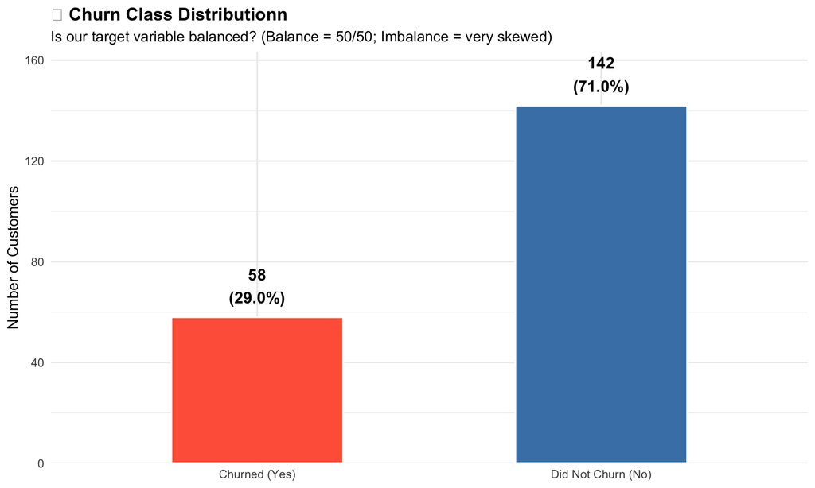

```r
# ── Why check class balance? ────────────────────────────────────────────────
# If 95% of customers are "No" and only 5% are "Yes", a naive model that
# always predicts "No" gets 95% accuracy but is completely useless at
# identifying churners — the very thing we care about most.
#
# We visualise the split to know whether we need techniques like:
#   - Oversampling (SMOTE)
#   - Class weights
#   - Different evaluation metrics (AUC-ROC over accuracy)

churn_counts <- as.data.frame(table(df$churn))
names(churn_counts) <- c("Churn", "Count")
churn_counts$Pct   <- churn_counts$Count / sum(churn_counts$Count)
churn_counts$Label <- c("Did Not Churn (No)", "Churned (Yes)")

ggplot(churn_counts, aes(x = Label, y = Count, fill = Label)) +
  geom_col(width = 0.5, colour = "white", linewidth = 0.8) +
  geom_text(
    aes(label = paste0(Count, "\n(", percent(Pct, accuracy = 0.1), ")")),
    vjust = -0.4, fontface = "bold", size = 5
  ) +
  scale_fill_manual(values = c("Did Not Churn (No)" = "steelblue",
                                "Churned (Yes)"      = "tomato")) +
  scale_y_continuous(expand = expansion(mult = c(0, 0.15))) +
  labs(
    title    = "📊 Churn Class Distribution",
    subtitle = "Is our target variable balanced? (Balance = 50/50; Imbalance = very skewed)",
    x = NULL, y = "Number of Customers"
  ) +
  theme_minimal(base_size = 13) +
  theme(legend.position = "none",
        plot.title = element_text(face = "bold"))
```

> **Interpret this chart:** If the split is severely unequal (e.g. 90/10), accuracy alone is misleading. We should rely on AUC-ROC and Log-Loss — which we do in Step 7.

# 5 Step 4 — Feature Selection Using Correlation

> **Teaching note:** Putting every available column into a model is tempting but harmful. Irrelevant features add noise. Correlated features (multicollinearity) distort coefficient estimates. We are deliberate about which features we include.

## 5.1 4a — Why Feature Selection Matters

| Problem | What happens without selection |
| --- | --- |
| **Noise features** | Model learns spurious patterns, generalises poorly |
| **Multicollinearity** | Two correlated features share variance → coefficients become unstable and hard to interpret |
| **Overfitting** | Model memorises training data but fails on new data |

## 5.2 4b — Correlation of Each Feature With Churn

```r
# ── Strategy ─────────────────────────────────────────────────────────────────
# We compute the Pearson correlation between each numeric feature and the
# binary churn outcome (0/1). This is called "point-biserial correlation"
# when one variable is binary — it is mathematically identical to Pearson r.
#
# Threshold: keep features where |r| > 0.10
# Features with |r| ≤ 0.10 have almost no linear relationship with churn
# and are unlikely to contribute meaningfully to the model.

# Temporarily convert churn back to 0/1 numeric for correlation computation
churn_numeric <- as.numeric(df$churn) - 1  # "Yes"=2→1, "No"=1→0

# Identify numeric columns (excluding churn)
numeric_cols <- df %>%
  select(where(is.numeric)) %>%
  names()

# Compute correlation of every numeric feature with churn
corr_with_churn <- sapply(numeric_cols, function(col) {
  cor(df[[col]], churn_numeric, use = "complete.obs")
})

# Build a sorted table (strongest absolute correlations first)
corr_df <- tibble(
  Feature     = names(corr_with_churn),
  Correlation = corr_with_churn
) %>%
  arrange(desc(abs(Correlation)))

cat("Pearson Correlation of each feature with 'churn' (sorted by |r|):\n\n")
```

```
Pearson Correlation of each feature with 'churn' (sorted by |r|):
```

```r
corr_df %>%
  mutate(
    Correlation = round(Correlation, 3),
    Strength    = case_when(
      abs(Correlation) >= 0.30 ~ "🔴 Strong",
      abs(Correlation) >= 0.10 ~ "🟡 Moderate",
      TRUE                     ~ "⚪ Weak (will drop)"
    )
  ) %>%
  kable(caption = "Feature–Churn Correlation (point-biserial)") %>%
  kable_styling(bootstrap_options = c("striped", "hover"), full_width = FALSE) %>%
  row_spec(which(abs(corr_df$Correlation) <= 0.10), color = "grey")
```

Feature–Churn Correlation (point-biserial)

| Feature | Correlation | Strength |
| --- | --- | --- |
| tenure | -0.377 | 🔴 Strong \| |
| employ | -0.338 | 🔴 Strong \| |
| loglong | -0.337 | 🔴 Strong \| |
| callcard | -0.311 | 🔴 Strong \| |
| longten | -0.295 | 🟡 Moderate \| |
| longmon | -0.292 | 🟡 Moderate \| |
| age | -0.288 | 🟡 Moderate \| |
| equip | 0.275 | 🟡 Moderate \| |
| address | -0.261 | 🟡 Moderate \| |
| equipmon | 0.255 | 🟡 Moderate \| |
| internet | 0.255 | 🟡 Moderate \| |
| ebill | 0.255 | 🟡 Moderate \| |
| cardten | -0.229 | 🟡 Moderate \| |
| ed | 0.216 | 🟡 Moderate \| |
| wiremon | 0.177 | 🟡 Moderate \| |
| cardmon | -0.177 | 🟡 Moderate \| |
| wireless | 0.174 | 🟡 Moderate \| |
| voice | 0.142 | 🟡 Moderate \| |
| pager | 0.125 | 🟡 Moderate \| |
| lninc | -0.117 | 🟡 Moderate \| |
| income | -0.091 | ⚪ Weak (will drop) \| |
| confer | -0.081 | ⚪ Weak (will drop) \| |
| logtoll | -0.070 | ⚪ Weak (will drop) \| |
| tollten | -0.059 | ⚪ Weak (will drop) \| |
| callwait | -0.053 | ⚪ Weak (will drop) \| |
| custcat | 0.015 | ⚪ Weak (will drop) \| |
| tollmon | 0.014 | ⚪ Weak (will drop) \| |

## 5.3 4c — Visualise Correlations

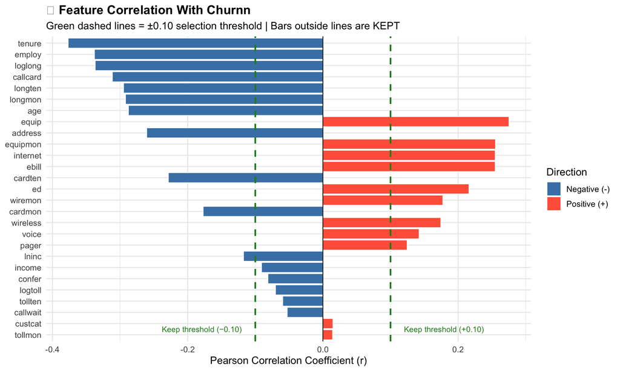

```r
# A horizontal bar chart makes it easy to see which features have strong
# positive (increases churn risk) vs negative (decreases churn risk) relationships

corr_df_plot <- corr_df %>%
  mutate(Direction = ifelse(Correlation > 0, "Positive (+)", "Negative (-)"))

ggplot(corr_df_plot,
       aes(x = Correlation,
           y = reorder(Feature, abs(Correlation)),
           fill = Direction)) +
  geom_col(colour = "white", linewidth = 0.4) +
  geom_vline(xintercept =  0.10, linetype = "dashed",
             colour = "forestgreen", linewidth = 0.9) +
  geom_vline(xintercept = -0.10, linetype = "dashed",
             colour = "forestgreen", linewidth = 0.9) +
  geom_vline(xintercept =  0, colour = "black", linewidth = 0.4) +
  scale_fill_manual(values = c("Negative (-)" = "steelblue",
                                "Positive (+)" = "tomato")) +
  annotate("text", x = 0.12, y = 1.5, label = "Keep threshold (+0.10)",
           colour = "forestgreen", size = 3.2, hjust = 0) +
  annotate("text", x = -0.12, y = 1.5, label = "Keep threshold (−0.10)",
           colour = "forestgreen", size = 3.2, hjust = 1) +
  labs(
    title    = "📊 Feature Correlation With Churn",
    subtitle = "Green dashed lines = ±0.10 selection threshold | Bars outside lines are KEPT",
    x = "Pearson Correlation Coefficient (r)",
    y = NULL, fill = "Direction"
  ) +
  theme_minimal(base_size = 12) +
  theme(plot.title = element_text(face = "bold"))
```

## 5.4 4d — Apply the Threshold

```r
# Keep only features with |correlation| > 0.10
THRESHOLD <- 0.10

selected_features <- corr_df %>%
  filter(abs(Correlation) > THRESHOLD) %>%
  pull(Feature)

cat(sprintf("✅ Features retained (|r| > %.2f): %d out of %d\n\n",
            THRESHOLD, length(selected_features), nrow(corr_df)))
```

```
✅ Features retained (|r| > 0.10): 20 out of 27
```

```r
cat("Selected features:\n")
```

```
Selected features:
```

```r
cat(paste(" •", selected_features, collapse = "\n"), "\n")
```

```
 • tenure
 • employ
 • loglong
 • callcard
 • longten
 • longmon
 • age
 • equip
 • address
 • equipmon
 • internet
 • ebill
 • cardten
 • ed
 • wiremon
 • cardmon
 • wireless
 • voice
 • pager
 • lninc
```

## 5.5 4e — Multicollinearity Check (Feature vs Feature)

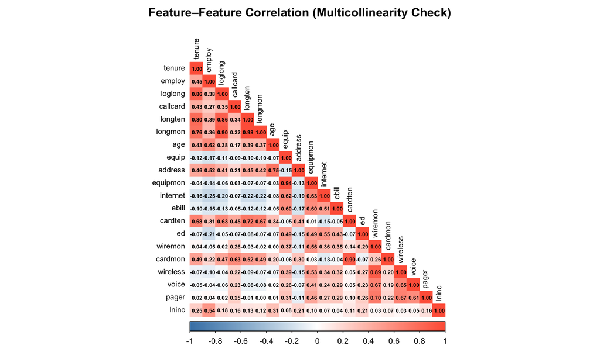

```r
# ── What is multicollinearity? ───────────────────────────────────────────────
# When two PREDICTOR features are highly correlated with EACH OTHER (not with
# churn, but with each other), including both in the model causes problems:
#   - Coefficient estimates become unstable (high variance)
#   - Standard errors inflate → p-values become unreliable
#   - The model cannot tell which feature is doing the work
#
# Rule of thumb: if two features have |r| > 0.8 with each other, drop one.

feat_corr_matrix <- df %>%
  select(all_of(selected_features)) %>%
  cor(use = "complete.obs")

corrplot(
  feat_corr_matrix,
  method      = "color",
  type        = "lower",
  tl.cex      = 0.75,
  tl.col      = "black",
  addCoef.col = "black",
  number.cex  = 0.55,
  col         = colorRampPalette(c("steelblue", "white", "tomato"))(200),
  title       = "Feature–Feature Correlation (Multicollinearity Check)",
  mar         = c(0, 0, 2, 0)
)
```

## 5.6 4f — Remove Collinear Duplicates

```r
# ── What we found in the heatmap ────────────────────────────────────────────
# 'loglong' is the log-transform of 'longmon'  → same information, different scale
# 'lninc'   is the log-transform of 'income'   → same information, different scale
#
# Keeping both versions of the same information inflates variance of coefficient
# estimates and makes the model harder to interpret.
#
# DECISION: Keep the ORIGINAL variables (longmon, income) because:
#   - They are on an interpretable scale (minutes, dollars)
#   - The log transforms offer no additional information after normalisation

features_to_drop  <- c("loglong", "lninc")
selected_features <- setdiff(selected_features, features_to_drop)

cat(sprintf("✅ Final feature set: %d features (removed %d log-transform duplicates)\n\n",
            length(selected_features), length(features_to_drop)))
```

```
✅ Final feature set: 18 features (removed 2 log-transform duplicates)
```

```r
# Final feature table with correlation and interpretation
corr_df %>%
  filter(Feature %in% selected_features) %>%
  arrange(desc(abs(Correlation))) %>%
  mutate(
    Correlation = round(Correlation, 3),
    Interpretation = ifelse(
      Correlation > 0,
      "▲ Higher value → more likely to churn",
      "▼ Higher value → less likely to churn"
    )
  ) %>%
  kable(caption = "✅ Final selected features with churn correlation") %>%
  kable_styling(bootstrap_options = c("striped", "hover"), full_width = FALSE)
```

✅ Final selected features with churn correlation

| Feature | Correlation | Interpretation |
| --- | --- | --- |
| tenure | -0.377 | ▼ Higher value → less likely to churn |
| employ | -0.338 | ▼ Higher value → less likely to churn |
| callcard | -0.311 | ▼ Higher value → less likely to churn |
| longten | -0.295 | ▼ Higher value → less likely to churn |
| longmon | -0.292 | ▼ Higher value → less likely to churn |
| age | -0.288 | ▼ Higher value → less likely to churn |
| equip | 0.275 | ▲ Higher value → more likely to churn |
| address | -0.261 | ▼ Higher value → less likely to churn |
| equipmon | 0.255 | ▲ Higher value → more likely to churn |
| internet | 0.255 | ▲ Higher value → more likely to churn |
| ebill | 0.255 | ▲ Higher value → more likely to churn |
| cardten | -0.229 | ▼ Higher value → less likely to churn |
| ed | 0.216 | ▲ Higher value → more likely to churn |
| wiremon | 0.177 | ▲ Higher value → more likely to churn |
| cardmon | -0.177 | ▼ Higher value → less likely to churn |
| wireless | 0.174 | ▲ Higher value → more likely to churn |
| voice | 0.142 | ▲ Higher value → more likely to churn |
| pager | 0.125 | ▲ Higher value → more likely to churn |

# 6 Step 5 — Normalisation (Ensuring Model Convergence)

> **Teaching note:** This step is often skipped by beginners, and then they wonder why the model gives weird results or fails to converge.

## 6.1 Why Normalisation Is Essential for Logistic Regression

R’s `glm()` fits logistic regression using an algorithm called **Iteratively Reweighted Least Squares (IRLS)**. This algorithm takes gradient steps — small updates to the coefficients at each iteration.

**The problem:** If `income` ranges from 0 to 1600 and `wireless` is only 0 or 1, the gradient steps for each feature are on completely different scales. The optimizer either:

- Takes tiny steps for large-scale features (very slow convergence)
- Overshoots for small-scale features (oscillation / failure to converge)

**The fix:** StandardScaling — subtract the mean and divide by the standard deviation:

$$z = \frac{x - \mu}{\sigma}$$

After scaling, every feature has **mean = 0** and **standard deviation = 1**. The optimizer works in a uniform space and converges quickly.

> ⚠️ **Critical rule — No Data Leakage:** We fit the scaler on **training data only**, then apply it to both train and test. If we fit on the full dataset (including test), the test set “bleeds” information into training — an error called **data leakage** that inflates performance metrics artificially.

## 6.2 5a — Train / Test Split First

```r
# ── Prepare modelling dataset ─────────────────────────────────────────────────
# Select only our chosen features + the target variable
model_df <- df %>%
  select(all_of(c(selected_features, "churn")))

# ── Stratified 80/20 split ────────────────────────────────────────────────────
# "Stratified" means the churn proportion is preserved in both splits.
# Without stratification, by random chance the test set might have very few
# churners — making evaluation unreliable.
#
# set.seed(42) ensures reproducibility: same split every time we run this notebook

set.seed(42)

train_idx <- createDataPartition(
  model_df$churn,
  p     = 0.80,   # 80% training, 20% test
  list  = FALSE,
  times = 1
)

train_df <- model_df[ train_idx, ]  # rows IN the partition → training
test_df  <- model_df[-train_idx, ]  # rows NOT in partition → test

cat("━━━━━━━━━━━━━━━━━━━━━━━━━━━━━━━━━━━\n")
```

```
━━━━━━━━━━━━━━━━━━━━━━━━━━━━━━━━━━━
```

```r
cat(" TRAIN / TEST SPLIT\n")
```

```
 TRAIN / TEST SPLIT
```

```r
cat("━━━━━━━━━━━━━━━━━━━━━━━━━━━━━━━━━━━\n")
```

```
━━━━━━━━━━━━━━━━━━━━━━━━━━━━━━━━━━━
```

```r
cat(sprintf("  Training samples : %d (%.0f%%)\n", nrow(train_df), 100*nrow(train_df)/nrow(model_df)))
```

```
  Training samples : 161 (80%)
```

```r
cat(sprintf("  Test samples     : %d (%.0f%%)\n", nrow(test_df),  100*nrow(test_df)/nrow(model_df)))
```

```
  Test samples     : 39 (20%)
```

```r
cat(sprintf("\n  Churn rate — train : %s\n", percent(mean(train_df$churn == "Yes"), 0.1)))
```

```
  Churn rate — train : 29.2%
```

```r
cat(sprintf("  Churn rate — test  : %s  (should match train ≈ stratified)\n",
            percent(mean(test_df$churn == "Yes"), 0.1)))
```

```
  Churn rate — test  : 28.2%  (should match train ≈ stratified)
```

## 6.3 5b — Fit Scaler and Transform

```r
# ── Step 1: Fit preProcess on TRAINING DATA ONLY ──────────────────────────────
# "center" = subtract the training mean from each feature
# "scale"  = divide by the training standard deviation
# Both together = StandardScaler (z-score normalisation)

preproc <- preProcess(
  train_df %>% select(-churn),    # NEVER include the target in the scaler
  method = c("center", "scale")
)

# ── Step 2: Apply transformation to BOTH sets ─────────────────────────────────
# predict() here does NOT make predictions — it APPLIES the transformation.
# (Confusingly named, but this is standard caret usage)
train_scaled <- predict(preproc, train_df)   # transform training set
test_scaled  <- predict(preproc, test_df)    # apply SAME parameters to test set

# ── Step 3: Verify the scaling worked ────────────────────────────────────────
means_after <- train_scaled %>% select(-churn) %>% summarise(across(everything(), mean))
sds_after   <- train_scaled %>% select(-churn) %>% summarise(across(everything(), sd))

cat("Post-scaling verification (training set):\n")
```

```
Post-scaling verification (training set):
```

```r
cat(sprintf("  Grand mean of all feature means : %.8f  ← should be ≈ 0\n",
            mean(unlist(means_after))))
```

```
  Grand mean of all feature means : -0.00000000  ← should be ≈ 0
```

```r
cat(sprintf("  Grand mean of all feature SDs   : %.8f  ← should be ≈ 1\n",
            mean(unlist(sds_after))))
```

```
  Grand mean of all feature SDs   : 1.00000000  ← should be ≈ 1
```

```r
cat("\n✅ Scaling confirmed.\n")
```

```
✅ Scaling confirmed.
```

## 6.4 5c — Visualise the Effect of Scaling

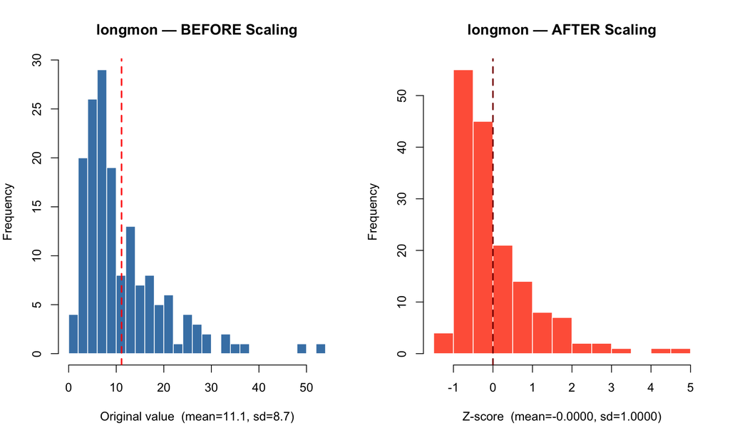

```r
# Let us visually confirm what scaling does to one feature ('longmon')
# BEFORE: raw values (wide spread, potentially skewed)
# AFTER : z-scores (centred at 0, SD = 1)

feat <- "longmon"

before_vals <- train_df[[feat]]
after_vals  <- train_scaled[[feat]]

# Two side-by-side histograms
par(mfrow = c(1, 2), mar = c(5, 4, 4, 2))

hist(before_vals,
     main   = paste(feat, "— BEFORE Scaling"),
     xlab   = sprintf("Original value  (mean=%.1f, sd=%.1f)",
                      mean(before_vals), sd(before_vals)),
     col    = "steelblue",
     border = "white",
     breaks = 20)
abline(v = mean(before_vals), col = "red", lwd = 2, lty = 2)

hist(after_vals,
     main   = paste(feat, "— AFTER Scaling"),
     xlab   = sprintf("Z-score  (mean=%.4f, sd=%.4f)",
                      mean(after_vals), sd(after_vals)),
     col    = "tomato",
     border = "white",
     breaks = 20)
abline(v = 0, col = "darkred", lwd = 2, lty = 2)
```

```r
par(mfrow = c(1, 1))
```

> **Notice:** The SHAPE of the distribution is unchanged — only the scale shifts. This is important: scaling does not distort the data, it simply re-expresses it in a common unit (standard deviations from the mean).

# 7 Step 6 — Train the Logistic Regression Model

> **Teaching note:** Once the data is properly prepared, the actual modelling step is surprisingly short. The hard work was in Steps 3–5.

## 7.1 How glm() Fits Logistic Regression

`glm(churn ~ ., family = binomial(link = "logit"), data = train_scaled)`

| Argument | Meaning |
| --- | --- |
| `churn ~ .` | Predict `churn` using ALL other columns as predictors |
| `family = binomial` | Tells R: outcome is binary → use logistic regression |
| `link = "logit"` | Use the log-odds (logit) link function — the standard for binary outcomes |

Internally, R uses **IRLS (Iteratively Reweighted Least Squares)** — an iterative algorithm that repeatedly adjusts the coefficients to maximise the likelihood of observing the training data.

```r
# ── Fit the model ─────────────────────────────────────────────────────────────
model <- glm(
  churn ~ .,
  data   = train_scaled,
  family = binomial(link = "logit")
)

cat("✅ Model trained successfully.\n\n")
```

```
✅ Model trained successfully.
```

```r
cat("What this model learns:\n")
```

```
What this model learns:
```

```r
cat("  logit(P(churn=Yes)) = β₀ + β₁·feature₁ + β₂·feature₂ + ... + βₙ·featureₙ\n\n")
```

```
  logit(P(churn=Yes)) = β₀ + β₁·feature₁ + β₂·feature₂ + ... + βₙ·featureₙ
```

```r
cat("  where logit(p) = log(p / (1-p))  ← log of the odds ratio\n")
```

```
  where logit(p) = log(p / (1-p))  ← log of the odds ratio
```

```r
cat("  To recover probability: P = 1 / (1 + e^(−linear predictor))\n")
```

```
  To recover probability: P = 1 / (1 + e^(−linear predictor))
```

## 7.2 6b — Model Summary & Coefficient Interpretation

```r
# ── Understanding the summary output ─────────────────────────────────────────
#
# Estimate  : β coefficient in LOG-ODDS units
#             Positive → feature INCREASES odds of churn
#             Negative → feature DECREASES odds of churn
#
# Std. Error: Uncertainty around the estimate
#             Larger = less confident in that coefficient
#
# z value   : Estimate / Std.Error  (Wald test statistic)
#             Large |z| → coefficient is far from zero → likely real effect
#
# Pr(>|z|)  : p-value
#             < 0.05 → statistically significant at 5% level  (*)
#             < 0.01 → (** )
#             < 0.001 → (***)

summary(model)
```

```
Call:
glm(formula = churn ~ ., family = binomial(link = "logit"), data = train_scaled)

Coefficients:
             Estimate Std. Error z value Pr(>|z|)
(Intercept) -1.481183   0.281372  -5.264 1.41e-07 ***
tenure      -1.025454   0.530934  -1.931   0.0534 .
employ      -0.471722   0.377430  -1.250   0.2114
callcard    -0.935115   0.394062  -2.373   0.0176 *
longten      1.204696   1.375199   0.876   0.3810
longmon     -0.650251   1.209261  -0.538   0.5908
age         -0.361140   0.408115  -0.885   0.3762
equip        0.491349   0.725955   0.677   0.4985
address      0.342190   0.403754   0.848   0.3967
equipmon    -0.157958   0.793123  -0.199   0.8421
internet     0.001752   0.302308   0.006   0.9954
ebill        0.304131   0.272921   1.114   0.2651
cardten     -0.630997   0.903174  -0.699   0.4848
ed           0.095874   0.287365   0.334   0.7387
wiremon      0.465465   0.501066   0.929   0.3529
cardmon      0.794448   0.831342   0.956   0.3393
wireless    -0.141104   0.440220  -0.321   0.7486
voice        0.085707   0.329375   0.260   0.7947
pager        0.374712   0.341393   1.098   0.2724
---
Signif. codes:  0 '***' 0.001 '**' 0.01 '*' 0.05 '.' 0.1 ' ' 1

(Dispersion parameter for binomial family taken to be 1)

    Null deviance: 194.45  on 160  degrees of freedom
Residual deviance: 134.83  on 142  degrees of freedom
AIC: 172.83

Number of Fisher Scoring iterations: 6
```

## 7.3 6c — Odds Ratio Interpretation

```r
# ── Why convert to Odds Ratios? ───────────────────────────────────────────────
# Log-odds coefficients are hard to interpret intuitively.
# Exponentiating them gives ODDS RATIOS — much easier to understand:
#
# Odds Ratio (OR) > 1 → feature INCREASES churn odds
# Odds Ratio (OR) < 1 → feature DECREASES churn odds
# Odds Ratio (OR) = 1 → feature has NO effect
#
# Example: OR = 1.5 for 'longmon' → a 1 SD increase in long-distance minutes
#           is associated with 50% higher odds of churning.

coef_table <- tidy(model, conf.int = TRUE) %>%
  filter(term != "(Intercept)") %>%
  mutate(
    OddsRatio  = round(exp(estimate), 3),
    OR_CI_Low  = round(exp(conf.low), 3),
    OR_CI_High = round(exp(conf.high), 3),
    p.value    = round(p.value, 4),
    Significant = case_when(
      p.value < 0.001 ~ "***",
      p.value < 0.01  ~ "** ",
      p.value < 0.05  ~ "*  ",
      TRUE            ~ "   "
    ),
    Effect = ifelse(OddsRatio > 1, "▲ Increases churn", "▼ Decreases churn")
  ) %>%
  select(term, OddsRatio, OR_CI_Low, OR_CI_High, p.value, Significant, Effect) %>%
  arrange(desc(OddsRatio))

coef_table %>%
  kable(caption = "Odds Ratios — How each feature affects churn odds (per 1 SD change)") %>%
  kable_styling(bootstrap_options = c("striped", "hover"), full_width = FALSE) %>%
  column_spec(7, bold = TRUE,
              color = ifelse(coef_table$Effect == "▲ Increases churn", "tomato", "steelblue"))
```

Odds Ratios — How each feature affects churn odds (per 1 SD change)

term

OddsRatio

OR_CI_Low

OR_CI_High

p.value

Significant

Effect

longten

3.336

0.202

50.936

0.3810

▲ Increases churn

cardmon

2.213

0.442

11.683

0.3393

▲ Increases churn

equip

1.635

0.386

6.836

0.4985

▲ Increases churn

wiremon

1.593

0.592

4.445

0.3529

▲ Increases churn

pager

1.455

0.746

2.888

0.2724

▲ Increases churn

address

1.408

0.639

3.166

0.3967

▲ Increases churn

ebill

1.355

0.794

2.336

0.2651

▲ Increases churn

ed

1.101

0.624

1.945

0.7387

▲ Increases churn

voice

1.089

0.557

2.061

0.7947

▲ Increases churn

internet

1.002

0.549

1.814

0.9954

▲ Increases churn

wireless

0.868

0.358

2.053

0.7486

▼ Decreases churn

equipmon

0.854

0.180

4.204

0.8421

▼ Decreases churn

age

0.697

0.302

1.523

0.3762

▼ Decreases churn

employ

0.624

0.288

1.294

0.2114

▼ Decreases churn

cardten

0.532

0.083

3.030

0.4848

▼ Decreases churn

longmon

0.522

0.046

5.736

0.5908

▼ Decreases churn

callcard

0.393

0.173

0.822

0.0176

▼ Decreases churn

tenure

0.359

0.124

1.021

0.0534

▼ Decreases churn

## 7.4 6d — Coefficient Forest Plot

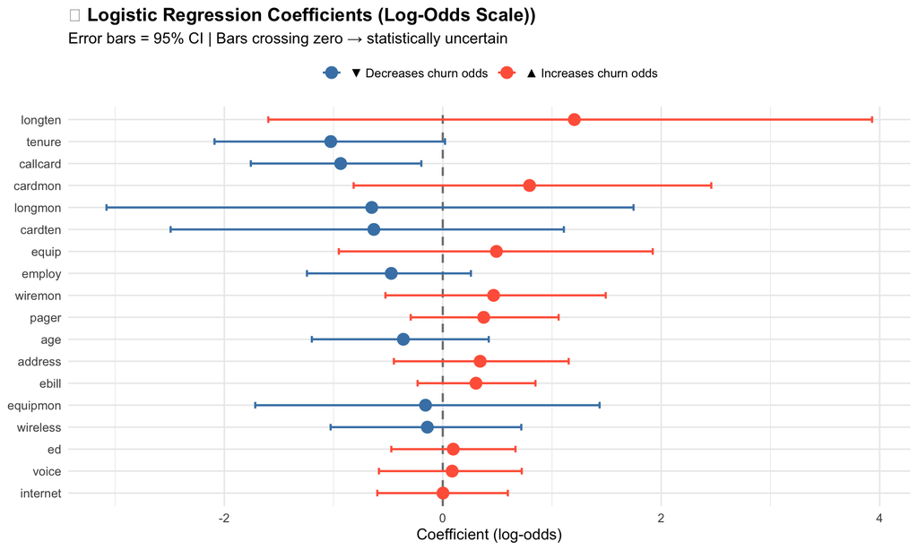

```r
# A forest plot shows coefficients with 95% confidence intervals.
# If the confidence interval bar crosses ZERO, the effect may not be
# statistically reliable (zero = no effect in log-odds scale).

coef_df <- tidy(model, conf.int = TRUE) %>%
  filter(term != "(Intercept)") %>%
  arrange(desc(abs(estimate)))

ggplot(coef_df, aes(x = estimate,
                     y = reorder(term, abs(estimate)),
                     colour = estimate > 0)) +
  geom_vline(xintercept = 0, colour = "grey50", linetype = "dashed", linewidth = 0.8) +
  geom_errorbarh(aes(xmin = conf.low, xmax = conf.high),
                 height = 0.3, linewidth = 0.8) +
  geom_point(size = 4) +
  scale_colour_manual(
    values = c("FALSE" = "steelblue", "TRUE" = "tomato"),
    labels = c("FALSE" = "▼ Decreases churn odds",
               "TRUE"  = "▲ Increases churn odds")
  ) +
  labs(
    title    = "🎯 Logistic Regression Coefficients (Log-Odds Scale)",
    subtitle = "Error bars = 95% CI | Bars crossing zero → statistically uncertain",
    x = "Coefficient (log-odds)",
    y = NULL,
    colour = NULL
  ) +
  theme_minimal(base_size = 12) +
  theme(legend.position = "top",
        plot.title = element_text(face = "bold"))
```

# 8 Step 7 — Model Evaluation

> **Teaching note:** Accuracy alone is a terrible metric for imbalanced classification problems. We use multiple complementary metrics to get a complete picture of model quality.

## 8.1 7a — The Loss Function: Log-Loss (Binary Cross-Entropy)

The **loss function** is the mathematical measure that logistic regression minimises during training. For binary classification, this is **log-loss** (also called binary cross-entropy):

$$\text{LogLoss} = -\frac{1}{n} \sum_{i=1}^{n} \left[ y_i \cdot \log(\hat{p}_i) + (1-y_i) \cdot \log(1-\hat{p}_i) \right]$$

**Intuition:** Log-loss heavily penalises **confident wrong predictions**. If the model says P(churn)=0.99 but the customer did NOT churn, the log-loss for that observation is very large. The model learns to be well-calibrated — not just directionally correct, but appropriately uncertain.

| Log-Loss Value | Interpretation |
| --- | --- |
| → 0 | Perfect model |
| 0.693 (= ln 2) | Random classifier (baseline) |
| > 0.693 | Worse than random |

```r
# ── Get predicted probabilities ───────────────────────────────────────────────
# type = "response" returns probabilities P(churn=Yes) ∈ [0,1]
# type = "link"     would return log-odds (not what we want for metrics)

train_prob <- predict(model, newdata = train_scaled, type = "response")
test_prob  <- predict(model, newdata = test_scaled,  type = "response")

# Convert factor to 0/1 for metric functions
y_train_num <- as.numeric(train_scaled$churn) - 1  # "Yes"→1, "No"→0
y_test_num  <- as.numeric(test_scaled$churn)  - 1

# ── Compute Log-Loss ──────────────────────────────────────────────────────────
# MLmetrics::LogLoss(y_pred, y_true)  ← note argument order!
train_logloss <- LogLoss(train_prob, y_train_num)
test_logloss  <- LogLoss(test_prob,  y_test_num)

cat("━━━━━━━━━━━━━━━━━━━━━━━━━━━━━━━━━━━━━━━━━\n")
```

```
━━━━━━━━━━━━━━━━━━━━━━━━━━━━━━━━━━━━━━━━━
```

```r
cat(" LOSS FUNCTION — Binary Cross-Entropy\n")
```

```
 LOSS FUNCTION — Binary Cross-Entropy
```

```r
cat("━━━━━━━━━━━━━━━━━━━━━━━━━━━━━━━━━━━━━━━━━\n")
```

```
━━━━━━━━━━━━━━━━━━━━━━━━━━━━━━━━━━━━━━━━━
```

```r
cat(sprintf("  Training log-loss  : %.4f\n", train_logloss))
```

```
  Training log-loss  : 0.4187
```

```r
cat(sprintf("  Test     log-loss  : %.4f\n", test_logloss))
```

```
  Test     log-loss  : 0.4745
```

```r
cat(sprintf("  Baseline (random)  : 0.6931\n"))
```

```
  Baseline (random)  : 0.6931
```

```r
cat(sprintf("  Improvement vs baseline: %.1f%%\n\n",
            100 * (0.6931 - test_logloss) / 0.6931))
```

```
  Improvement vs baseline: 31.5%
```

```r
# Overfitting check
gap <- test_logloss - train_logloss
cat(sprintf("  Train–Test gap     : %.4f", gap))
```

```
  Train–Test gap     : 0.0558
```

```r
if (gap > 0.05) {
  cat("  ⚠️  Possible overfitting — test loss notably higher than train\n")
} else {
  cat("  ✅ Generalises well — train and test loss are close\n")
}
```

```
  ⚠️  Possible overfitting — test loss notably higher than train
```

```r
cat("\n")
```

```r
if (test_logloss < 0.40) {
  cat("  🟢 Excellent — model is substantially better than random\n")
} else if (test_logloss < 0.55) {
  cat("  🟡 Good — model meaningfully better than random\n")
} else if (test_logloss < 0.65) {
  cat("  🟠 Modest — only slightly better than random\n")
} else {
  cat("  🔴 Poor — model near random; revisit feature selection\n")
}
```

```
  🟡 Good — model meaningfully better than random
```

## 8.2 7b — AUC-ROC: Ranking Quality

```r
# ── What is AUC-ROC? ──────────────────────────────────────────────────────────
# ROC = Receiver Operating Characteristic curve
# It plots True Positive Rate (Sensitivity) vs False Positive Rate at every
# possible probability threshold.
#
# AUC = Area Under the ROC Curve
#   AUC = 1.0  → perfect model (ranks every churner above every non-churner)
#   AUC = 0.5  → random model (no discrimination ability)
#   AUC < 0.5  → worse than random (model is inverted)
#
# AUC is threshold-independent — it measures how well the model RANKS
# customers by churn risk, regardless of where you draw the cutoff.
# This makes it excellent for imbalanced datasets.

roc_obj <- roc(
  response  = test_scaled$churn,
  predictor = test_prob,
  levels    = c("No", "Yes"),
  direction = "<"  # higher probability = more likely "Yes"
)

auc_val <- auc(roc_obj)
cat(sprintf("AUC-ROC Score: %.4f\n", auc_val))
```

```
AUC-ROC Score: 0.8149
```

```r
cat(sprintf("Interpretation: The model correctly ranks a random churner\n"))
```

```
Interpretation: The model correctly ranks a random churner
```

```r
cat(sprintf("above a random non-churner %.1f%% of the time.\n", auc_val * 100))
```

```
above a random non-churner 81.5% of the time.
```

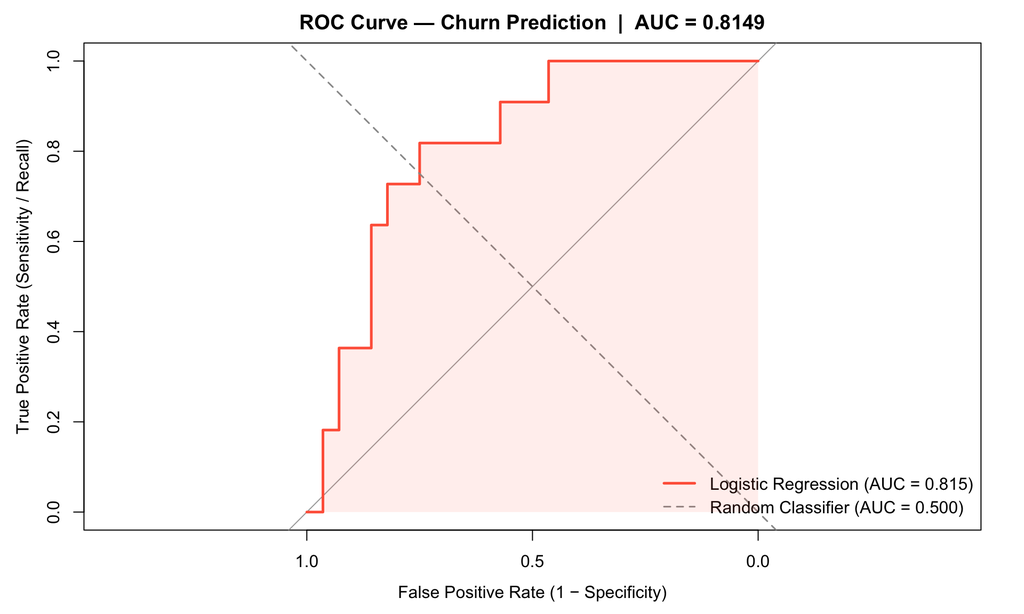

```r
# ── Plot ROC curve ────────────────────────────────────────────────────────────
plot(
  roc_obj,
  col  = "tomato",
  lwd  = 2.5,
  main = sprintf("ROC Curve — Churn Prediction  |  AUC = %.4f", auc_val),
  xlab = "False Positive Rate (1 − Specificity)",
  ylab = "True Positive Rate (Sensitivity / Recall)"
)
abline(a = 0, b = 1, lty = 2, col = "grey60", lwd = 1.5)  # random baseline
legend(
  "bottomright",
  legend = c(sprintf("Logistic Regression (AUC = %.3f)", auc_val),
             "Random Classifier (AUC = 0.500)"),
  col = c("tomato", "grey60"),
  lwd = c(2.5, 1.5),
  lty = c(1, 2),
  bty = "n"
)

# Shade the area under the curve for visual emphasis
polygon(
  c(roc_obj$specificities, 0),
  c(roc_obj$sensitivities, 0),
  col = adjustcolor("tomato", alpha.f = 0.1),
  border = NA
)
```

## 8.3 7c — Confusion Matrix & Classification Metrics

```r
# ── Convert probabilities to class predictions ────────────────────────────────
# At threshold = 0.5: if P(churn) > 0.5 → predict "Yes", else → "No"
#
# NOTE: 0.5 is the DEFAULT threshold, not necessarily the BEST one.
# In practice, you might lower it (e.g. 0.3) to catch more churners
# at the cost of more false alarms. This is a BUSINESS decision.

test_pred <- ifelse(test_prob > 0.5, "Yes", "No") %>%
  factor(levels = c("No", "Yes"))

# ── Confusion Matrix ──────────────────────────────────────────────────────────
# confusionMatrix() gives us a rich summary:
#   TP = True Positive  (predicted Yes, was Yes)  → correctly caught churner
#   TN = True Negative  (predicted No,  was No)   → correctly kept customer
#   FP = False Positive (predicted Yes, was No)   → unnecessary intervention
#   FN = False Negative (predicted No,  was Yes)  → missed churner (costly!)
#
# "positive = Yes" tells R that "Yes" (churn) is what we are trying to detect

cm <- confusionMatrix(
  data      = test_pred,
  reference = test_scaled$churn,
  positive  = "Yes"
)

print(cm)
```

```
Confusion Matrix and Statistics

          Reference
Prediction No Yes
       No  24   7
       Yes  4   4

               Accuracy : 0.7179
                 95% CI : (0.5513, 0.85)
    No Information Rate : 0.7179
    P-Value [Acc > NIR] : 0.5804

                  Kappa : 0.2407

 Mcnemar's Test P-Value : 0.5465

            Sensitivity : 0.3636
            Specificity : 0.8571
         Pos Pred Value : 0.5000
         Neg Pred Value : 0.7742
             Prevalence : 0.2821
         Detection Rate : 0.1026
   Detection Prevalence : 0.2051
      Balanced Accuracy : 0.6104

       'Positive' Class : Yes
```

## 8.4 7d — Confusion Matrix Heatmap

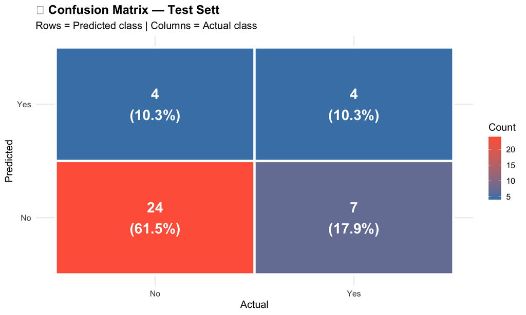

```r
# A heatmap version of the confusion matrix is easier to scan at a glance.
# Dark red = high count, dark blue = low count

cm_table <- as.data.frame(cm$table)
names(cm_table) <- c("Predicted", "Actual", "Count")

# Add percentage labels
total <- sum(cm_table$Count)
cm_table$Pct <- percent(cm_table$Count / total, accuracy = 0.1)
cm_table$Label <- paste0(cm_table$Count, "\n(", cm_table$Pct, ")")

ggplot(cm_table, aes(x = Actual, y = Predicted, fill = Count)) +
  geom_tile(colour = "white", linewidth = 1.5) +
  geom_text(aes(label = Label), size = 7, fontface = "bold", colour = "white") +
  scale_fill_gradient(low = "steelblue", high = "tomato") +
  labs(
    title    = "📊 Confusion Matrix — Test Set",
    subtitle = "Rows = Predicted class | Columns = Actual class",
    fill     = "Count"
  ) +
  theme_minimal(base_size = 14) +
  theme(plot.title = element_text(face = "bold"))
```

## 8.5 7e — Metrics Summary Table

```r
# Pull all key metrics from the confusionMatrix object and display in one table

accuracy  <- cm$overall["Accuracy"]
precision <- cm$byClass["Precision"]   # of all predicted churn, how many were right?
recall    <- cm$byClass["Recall"]      # of all actual churners, how many did we catch?
f1        <- cm$byClass["F1"]          # harmonic mean of precision and recall
specificity <- cm$byClass["Specificity"]  # of all non-churners, how many did we correctly label?

metrics_table <- tibble(
  Metric = c("Accuracy", "Precision", "Recall (Sensitivity)",
             "Specificity", "F1-Score", "Log-Loss", "AUC-ROC"),
  Value  = c(
    percent(accuracy, 0.1),
    percent(precision, 0.1),
    percent(recall, 0.1),
    percent(specificity, 0.1),
    round(f1, 4),
    round(test_logloss, 4),
    round(auc_val, 4)
  ),
  Interpretation = c(
    "% of all predictions that are correct",
    "% of predicted churners who actually churned",
    "% of actual churners we successfully identified",
    "% of actual non-churners we correctly identified",
    "Balance between Precision and Recall (1.0 = perfect)",
    "Lower is better | 0.693 = random baseline",
    "Higher is better | 0.5 = random | 1.0 = perfect"
  )
)

metrics_table %>%
  kable(caption = "📋 Complete Model Evaluation — Test Set") %>%
  kable_styling(bootstrap_options = c("striped", "hover"), full_width = FALSE) %>%
  row_spec(5:7, bold = TRUE, background = "#f0f4f8")
```

📋 Complete Model Evaluation — Test Set

| Metric | Value | Interpretation |
| --- | --- | --- |
| Accuracy | 71.8% | % of all predictions that are correct |
| Precision | 50.0% | % of predicted churners who actually churned |
| Recall (Sensitivity) | 36.4% | % of actual churners we successfully identified |
| Specificity | 85.7% | % of actual non-churners we correctly identified |
| F1-Score | 0.4211 | Balance between Precision and Recall (1.0 = perfect) |
| Log-Loss | 0.4745 | Lower is better &#124; 0.693 = random baseline |
| AUC-ROC | 0.8149 | Higher is better &#124; 0.5 = random &#124; 1.0 = perfect |

> **Which metric matters most here?** In a churn problem, **Recall** (catching actual churners) is often more important than Precision. A missed churner loses revenue permanently; a false alarm costs one retention call. Business context drives which metric to optimise.

# 9 Step 8 — Final Summary & Interpretation

```r
cat("══════════════════════════════════════════════════\n")
```

```
══════════════════════════════════════════════════
```

```r
cat("  CHURN PREDICTION MODEL — COMPLETE SUMMARY\n")
```

```
  CHURN PREDICTION MODEL — COMPLETE SUMMARY
```

```r
cat("══════════════════════════════════════════════════\n\n")
```

```
══════════════════════════════════════════════════
```

```r
cat("  DATA\n")
```

```
  DATA
```

```r
cat(sprintf("  ├─ Dataset          : %d customers, %d total columns\n", nrow(df), ncol(df)))
```

```
  ├─ Dataset          : 200 customers, 28 total columns
```

```r
cat(sprintf("  ├─ Features used    : %d (after correlation filtering)\n", length(selected_features)))
```

```
  ├─ Features used    : 18 (after correlation filtering)
```

```r
cat(sprintf("  └─ Train/Test split : 80%%/20%% stratified (seed=42)\n\n"))
```

```
  └─ Train/Test split : 80%/20% stratified (seed=42)
```

```r
cat("  PREPROCESSING\n")
```

```
  PREPROCESSING
```

```r
cat("  ├─ Response variable cast to factor (required for glm binomial)\n")
```

```
  ├─ Response variable cast to factor (required for glm binomial)
```

```r
cat("  ├─ Features filtered: |Pearson r| > 0.10 with churn\n")
```

```
  ├─ Features filtered: |Pearson r| > 0.10 with churn
```

```r
cat("  ├─ Log-transform duplicates removed: loglong, lninc\n")
```

```
  ├─ Log-transform duplicates removed: loglong, lninc
```

```r
cat("  └─ StandardScaler applied (center + scale, fit on train only)\n\n")
```

```
  └─ StandardScaler applied (center + scale, fit on train only)
```

```r
cat("  MODEL\n")
```

```
  MODEL
```

```r
cat("  └─ glm(family = binomial(link = 'logit')) — Logistic Regression\n\n")
```

```
  └─ glm(family = binomial(link = 'logit')) — Logistic Regression
```

```r
cat("  PERFORMANCE — TEST SET\n")
```

```
  PERFORMANCE — TEST SET
```

```r
cat(sprintf("  ├─ Accuracy   : %s\n",  percent(accuracy,    0.1)))
```

```
  ├─ Accuracy   : 71.8%
```

```r
cat(sprintf("  ├─ Precision  : %s\n",  percent(precision,   0.1)))
```

```
  ├─ Precision  : 50.0%
```

```r
cat(sprintf("  ├─ Recall     : %s\n",  percent(recall,      0.1)))
```

```
  ├─ Recall     : 36.4%
```

```r
cat(sprintf("  ├─ Specificity: %s\n",  percent(specificity, 0.1)))
```

```
  ├─ Specificity: 85.7%
```

```r
cat(sprintf("  ├─ F1-Score   : %.4f\n", f1))
```

```
  ├─ F1-Score   : 0.4211
```

```r
cat(sprintf("  ├─ Log-Loss   : %.4f  (random baseline: 0.6931)\n", test_logloss))
```

```
  ├─ Log-Loss   : 0.4745  (random baseline: 0.6931)
```

```r
cat(sprintf("  └─ AUC-ROC    : %.4f  (random baseline: 0.5000)\n", auc_val))
```

```
  └─ AUC-ROC    : 0.8149  (random baseline: 0.5000)
```

```r
cat("══════════════════════════════════════════════════\n")
```

```
══════════════════════════════════════════════════
```

# 10 📚 Complete Concepts Recap

| Concept | R Tool | Why It Matters |
| --- | --- | --- |
| **Binary outcome** | `factor(churn, levels=c(0,1))` | Required for `glm()` to run logistic, not linear regression |
| **Sigmoid function** | Built into `glm(family=binomial)` | Maps linear predictor → valid probability [0,1] |
| **Feature selection** | Pearson correlation, `\\|r\\| > 0.10` | Reduces noise and multicollinearity |
| **StandardScaler** | `caret::preProcess("center","scale")` | Ensures IRLS optimizer converges correctly |
| **No data leakage** | Fit scaler on train only | Prevents inflated test performance |
| **Log-Loss** | `MLmetrics::LogLoss()` | The actual loss function — penalises confident wrong predictions |
| **AUC-ROC** | `pROC::roc()` + `auc()` | Threshold-independent ranking quality metric |
| **Confusion Matrix** | `caret::confusionMatrix()` | Shows TP/TN/FP/FN and derived metrics |
| **Odds Ratios** | `exp(coef(model))` | Interpretable effect sizes (how much each feature multiplies churn odds) |

# 11 🚀 Suggested Next Steps

These are logical extensions to explore after mastering this notebook:

**1. Handle Class Imbalance**

```r
# Add class weights to penalise missing churners more heavily
model_weighted <- glm(churn ~ ., data = train_scaled,
                      family = binomial,
                      weights = ifelse(train_scaled$churn == "Yes", 3, 1))
```

**2. Threshold Optimisation**

```r
# Find the threshold that maximises F1-Score (not just 0.5 default)
thresholds <- seq(0.1, 0.9, by = 0.05)
# evaluate each threshold on validation set and pick the best
```

**3. Regularised Logistic Regression (LASSO)**

```r
library(glmnet)
# L1 penalty automatically shrinks unimportant coefficients to zero
# Gives built-in feature selection
```

**4. Stepwise Feature Selection**

```r
# Forward/backward/both stepwise using AIC
model_step <- step(model, direction = "both")
```

**5. Compare With Tree-Based Models**

```r
library(randomForest)
library(xgboost)
# Non-linear models can capture interactions logistic regression misses
```

*🎉 End of notebook. You now have a solid foundation in logistic regression — from data preparation to model interpretation. Happy modelling!*